# LASSO Logistic Regression

Dataset: `credit_Default.csv`

We will use Credit Card Default Data for this lab and illustration. The business problem is to predict credit card default based on information about applicants. "response" is the response column that shows if they defaulted = 1 or did not default = 0.

## Step 0 — Load Data and EDA (we skip for now)

```python
# Imports
import os
import numpy as np
import pandas as pd
```

```
(12000, 23)
             LIMIT_BAL      EDUCATION MARRIAGE           AGE         PAY_0  \
count     12000.000000          12000    12000  12000.000000  12000.000000
unique             NaN              4        3           NaN           NaN
top                NaN  undergraduate   single           NaN           NaN
freq               NaN           5596     6332           NaN           NaN
mean     167501.333333            NaN      NaN     35.499667     -0.015750
std      130334.212375            NaN      NaN      9.226480      1.128616
min       10000.000000            NaN      NaN     21.000000     -2.000000
25%       50000.000000            NaN      NaN     28.000000     -1.000000
50%      140000.000000            NaN      NaN     34.000000      0.000000
75%      240000.000000            NaN      NaN     41.000000      0.000000
max     1000000.000000            NaN      NaN     79.000000      8.000000

               PAY_2         PAY_3         PAY_4         PAY_5         PAY_6  \
count   12000.000000  12000.000000  12000.000000  12000.000000  12000.000000
unique           NaN           NaN           NaN           NaN           NaN
top              NaN           NaN           NaN           NaN           NaN
freq             NaN           NaN           NaN           NaN           NaN
mean       -0.128000     -0.166667     -0.225583     -0.267833     -0.293083
std         1.192645      1.187226      1.152522      1.123478      1.136424
min        -2.000000     -2.000000     -2.000000     -2.000000     -2.000000
25%        -1.000000     -1.000000     -1.000000     -1.000000     -1.000000
50%         0.000000      0.000000      0.000000      0.000000      0.000000
75%         0.000000      0.000000      0.000000      0.000000      0.000000
max         7.000000      7.000000      7.000000      7.000000      8.000000

        ...      BILL_AMT4      BILL_AMT5      BILL_AMT6       PAY_AMT1  \
count   ...   12000.000000   12000.000000   12000.000000   12000.000000
unique  ...            NaN            NaN            NaN            NaN
top     ...            NaN            NaN            NaN            NaN
freq    ...            NaN            NaN            NaN            NaN
mean    ...   43101.557667   40314.199833   38821.438833    5766.057333
std     ...   64429.407522   61042.768474   59611.508898   15989.660757
min     ...  -81334.000000  -81334.000000 -339603.000000       0.000000
25%     ...    2411.000000    1863.250000    1308.750000    1000.000000
50%     ...   19077.500000   18244.000000   17130.000000    2128.000000
75%     ...   53117.250000   49927.250000   48938.000000    5006.000000
max     ...  891586.000000  927171.000000  961664.000000  493358.000000

```

[output cut: 16 more lines]

```
top               NaN           NaN
freq              NaN           NaN
mean      5432.712083      0.219333
std      19044.129946      0.413812
min          0.000000      0.000000
25%        142.750000      0.000000
50%       1500.000000      0.000000
75%       4061.750000      0.000000
max     528666.000000      1.000000

[11 rows x 23 columns]
response
0    9368
1    2632
Name: count, dtype: int64
```

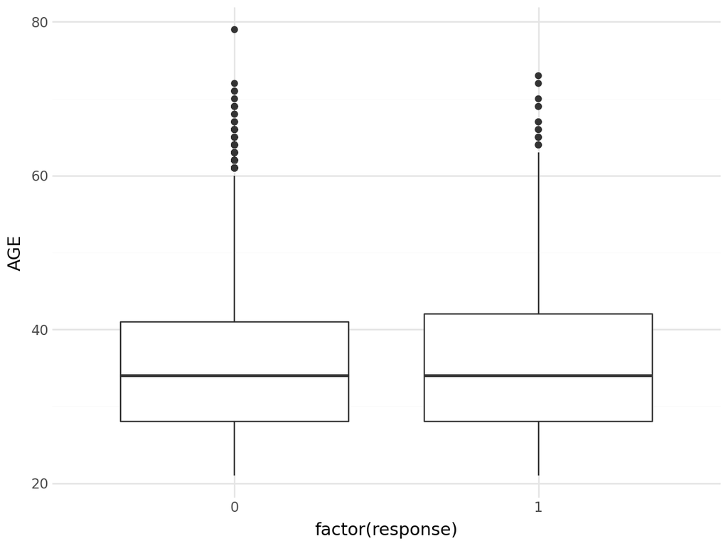

```python
# Expect the file to be in the same folder as this notebook
df = pd.read_csv('credit_Default.csv' )
print(df.shape)
print(df.describe(include='all'))
print(df['response'].value_counts())# summary stats

from plotnine import ggplot, aes, geom_boxplot, theme_minimal

p = (
    ggplot(df, aes(x='factor(response)', y='AGE'))
    + geom_boxplot()
    + theme_minimal()
)
display(p)
```

### We skip EDA in this lab but make sure you do this every time.

## Step 1: Partition our Data and Pre-processing

### For classification problems, first determine the classes of your response variable

```python
print(df["response"].dtype)                     # what type is it?
print(df["response"].unique())                  # list of unique labels
```

```
int64
[0 1]
```

### Next create a binary response where 1 indicates the event of interest and 0 indicates all other outcomes, ensuring that logistic regression coefficients and predicted probabilities refer to the correct class

```python
# Then set the positive class to 1, so we predict probability of default (and not probability of notdefault)
pos_class = 1
Y = (df["response"] == pos_class).astype(int)
X = pd.get_dummies(df.drop(columns=["response"]), drop_first=True)
```

```python
from sklearn.model_selection import train_test_split, StratifiedKFold

#Split into train/test sets
X_train, X_test, Y_train, Y_test = train_test_split(
    X, Y,
    test_size=0.3,     # 30% test, 70% train
    random_state=99,   # reproducibility
    shuffle=True       # shuffle before splitting
)

# Check shapes
X_train.shape, X_test.shape
```

```
((8400, 25), (3600, 25))
```

## Step 2 — Train/ Fit Model: LASSO Logistic Regression with Cross-Validation to choose best λ

We fit a logistic regression with LASSO penalty using scikit-learn’s `LogisticRegressionCV`, which automatically selects the best regularization strength via cross-validation.

Settings:

```python
# StandardScaler:     standardizes features (zero mean, unit variance)
#                     important for LASSO because they are scale-sensitive
from sklearn.preprocessing import StandardScaler
from sklearn.pipeline import Pipeline
from sklearn.linear_model import LogisticRegressionCV


# Stratified CV preserves class balance in each fold (important for classification)
cv = StratifiedKFold(n_splits=5, shuffle=True, random_state=20)
# Lambda grid: 0001 to 2.0 in 20 steps
lambdas = np.linspace(0.001, 2.0, 20)

logit_lasso_pipe = Pipeline([
    ("scaler", StandardScaler(with_mean=True)),     # scale numeric features
    ("model", LogisticRegressionCV(
        Cs=1/lambdas,             # C= 1/lambda which is specific to this package
        cv=cv,                    # 5-fold stratified CV
        penalty="l1",             # LASSO penalty
        solver="saga",            # supports L1 for logistic
        scoring="roc_auc",        # pick C that maximizes ROC AUC
        max_iter=2000,            # maximum iterations of the optimization algorithm
        n_jobs=-1,                # number of CPU cores used during the cross-validation loop
        refit=True                # refit on full training data with best C
          ))
])

logit_lasso_pipe.fit(X_train, Y_train)

best_C = logit_lasso_pipe.named_steps["model"].C_[0] # best 1/lambda value the minimizes AUC on holdout sets in cross-validation
best_lambda = 1.0 / best_C

print(f"Best C selected by CV: {best_C:.6g}   (λ = 1/C ≈ {best_lambda:.6g})")
```

```
Best C selected by CV: 0.863322   (λ = 1/C ≈ 1.15832)
```

### Coefficient Interpretation

Positive coefficient → higher values of that variable are associated with greater chance of default (response=1).

Negative coefficient → higher values of that variable are associated with lower chance of default.

Closer to zero → the feature has less impact on the response compared to others.

Zero → this variable has no impact on the response.

```python
# Get coefficients from the fitted LASSO model it automatically chooses the best C(1/λ)
lasso_model = logit_lasso_pipe.named_steps["model"]

# Match each coefficient with its feature name
coef_df = pd.DataFrame({
    "feature": X.columns,
    "coefficient": lasso_model.coef_.ravel()   # .coef_ is shape (1, n_features) for binary;
                                               # ravel() flattens it into a 1-D array
})

# Keep only non-zero coefficients (the ones LASSO thinks are important)
important_coefs = coef_df[coef_df["coefficient"] != 0]

# Sort by absolute size of the coefficient -- the larger the more important
important_coefs = important_coefs.reindex(
    important_coefs["coefficient"].abs().sort_values(ascending=False).index
)

print("Important features selected by LASSO:")
display(important_coefs)
```

```
Important features selected by LASSO:
```

|  | feature | coefficient |
| --- | --- | --- |
| 2 | PAY_0 | 0.690485 |
| 8 | BILL_AMT1 | -0.355755 |
| 9 | BILL_AMT2 | 0.235821 |
| 15 | PAY_AMT2 | -0.206869 |
| 12 | BILL_AMT5 | 0.165666 |
| 11 | BILL_AMT4 | -0.147350 |
| 21 | EDUCATION_others | -0.140802 |
| 14 | PAY_AMT1 | -0.127735 |
| 19 | PAY_AMT6 | -0.114002 |
| 3 | PAY_2 | 0.107825 |
| 0 | LIMIT_BAL | -0.096416 |
| 1 | AGE | 0.079490 |
| 24 | MARRIAGE_single | -0.070467 |
| 4 | PAY_3 | 0.070461 |
| 22 | EDUCATION_undergraduate | -0.067376 |
| 17 | PAY_AMT4 | -0.065861 |
| 5 | PAY_4 | 0.062887 |
| 20 | EDUCATION_high school | -0.035785 |
| 18 | PAY_AMT5 | -0.029208 |
| 16 | PAY_AMT3 | -0.022340 |
| 6 | PAY_5 | 0.018786 |
| 23 | MARRIAGE_others | -0.011439 |
| 10 | BILL_AMT3 | 0.005533 |
| 7 | PAY_6 | 0.000789 |